# [Group_10]_Project_Final_03

Group_10

## Đọc data

```r
data <- read.csv("bodyPerformance.csv")
data <- clean_names(data)
```

## **Các thống kê mô tả cho bộ dữ liệu**

### Kiểm tra cấu trúc của dữ liệu

```r
dim(data)
```

```
## [1] 13393    12
```

```r
glimpse(data)
```

```
## Rows: 13,393
## Columns: 12
## $ age                     <dbl> 27, 25, 31, 32, 28, 36, 42, 33, 54, 28, 42, 57…
## $ gender                  <chr> "M", "M", "M", "M", "M", "F", "F", "M", "M", "…
## $ height_cm               <dbl> 172.3, 165.0, 179.6, 174.5, 173.8, 165.4, 164.…
## $ weight_kg               <dbl> 75.24, 55.80, 78.00, 71.10, 67.70, 55.40, 63.7…
## $ body_fat                <dbl> 21.3, 15.7, 20.1, 18.4, 17.1, 22.0, 32.2, 36.9…
## $ diastolic               <dbl> 80, 77, 92, 76, 70, 64, 72, 84, 85, 81, 63, 69…
## $ systolic                <dbl> 130, 126, 152, 147, 127, 119, 135, 137, 165, 1…
## $ grip_force              <dbl> 54.9, 36.4, 44.8, 41.4, 43.5, 23.8, 22.7, 45.9…
## $ sit_and_bend_forward_cm <dbl> 18.4, 16.3, 12.0, 15.2, 27.1, 21.0, 0.8, 12.3,…
## $ sit_ups_counts          <dbl> 60, 53, 49, 53, 45, 27, 18, 42, 34, 55, 68, 0,…
## $ broad_jump_cm           <dbl> 217, 229, 181, 219, 217, 153, 146, 234, 148, 2…
## $ class                   <chr> "C", "A", "C", "B", "B", "B", "D", "B", "C", "…
```

### Thống kê mô tả cho dữ liệu

```r
summary(data)
```

```
##       age           gender            height_cm       weight_kg
##  Min.   :21.00   Length:13393       Min.   :125.0   Min.   : 26.30
##  1st Qu.:25.00   Class :character   1st Qu.:162.4   1st Qu.: 58.20
##  Median :32.00   Mode  :character   Median :169.2   Median : 67.40
##  Mean   :36.78                      Mean   :168.6   Mean   : 67.45
##  3rd Qu.:48.00                      3rd Qu.:174.8   3rd Qu.: 75.30
##  Max.   :64.00                      Max.   :193.8   Max.   :138.10
##     body_fat       diastolic        systolic       grip_force
##  Min.   : 3.00   Min.   :  0.0   Min.   :  0.0   Min.   : 0.00
##  1st Qu.:18.00   1st Qu.: 71.0   1st Qu.:120.0   1st Qu.:27.50
##  Median :22.80   Median : 79.0   Median :130.0   Median :37.90
##  Mean   :23.24   Mean   : 78.8   Mean   :130.2   Mean   :36.96
##  3rd Qu.:28.00   3rd Qu.: 86.0   3rd Qu.:141.0   3rd Qu.:45.20
##  Max.   :78.40   Max.   :156.2   Max.   :201.0   Max.   :70.50
##  sit_and_bend_forward_cm sit_ups_counts  broad_jump_cm      class
##  Min.   :-25.00          Min.   : 0.00   Min.   :  0.0   Length:13393
##  1st Qu.: 10.90          1st Qu.:30.00   1st Qu.:162.0   Class :character
##  Median : 16.20          Median :41.00   Median :193.0   Mode  :character
##  Mean   : 15.21          Mean   :39.77   Mean   :190.1
##  3rd Qu.: 20.70          3rd Qu.:50.00   3rd Qu.:221.0
##  Max.   :213.00          Max.   :80.00   Max.   :303.0
```

### Định nghĩa các biến định lượng và định tính

```r
numerical_features <- c("age", "height_cm", "weight_kg", "body_fat", "diastolic", "systolic",
                        "grip_force", "sit_and_bend_forward_cm", "sit_ups_counts",
                        "broad_jump_cm")

categorical_features <- c("gender", "class")
```

## **Tiền xử lý dữ liệu**

### Kiểm tra dữ liệu khuyết

```r
na_percentage <- colSums(is.na(data)) / nrow(data) * 100
na_percentage
```

```
##                     age                  gender               height_cm
##                       0                       0                       0
##               weight_kg                body_fat               diastolic
##                       0                       0                       0
##                systolic              grip_force sit_and_bend_forward_cm
##                       0                       0                       0
##          sit_ups_counts           broad_jump_cm                   class
##                       0                       0                       0
```

```r
aggr(data, ylab = c("Proportion of missings", "Pattern"), number = TRUE,
cex.axis = 0.6, cex.numbers = 0.5)
```

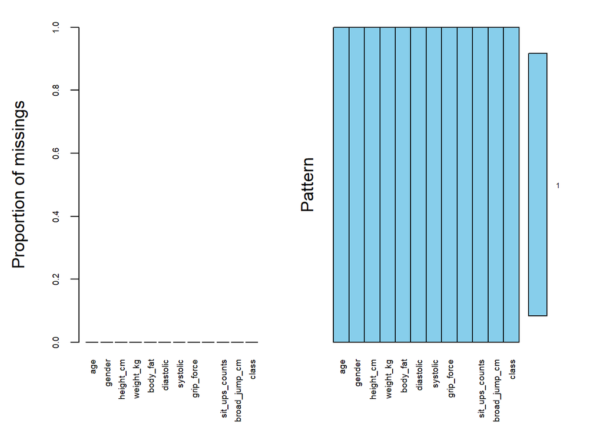

- Nhận xét nhanh: Không có dữ liệu bị thiếu

### Kiểm tra trùng lắp dữ liệu

```r
sum(duplicated(data))
```

```
## [1] 1
```

```r
data[duplicated(data), ]
```

```
##       age gender height_cm weight_kg body_fat diastolic systolic grip_force
## 12474  27      F       157      49.1     30.7        70       86       27.7
##       sit_and_bend_forward_cm sit_ups_counts broad_jump_cm class
## 12474                    19.7             51           167     A
```

- Có 1 dòng dữ liệu trùng lặp
- Với chỉ 1 dòng dữ liệu trùng lặp, tác động lên phân tích tổng thể có thể không đáng kể. Tuy nhiên, việc giữ lại các dòng trùng lặp có thể dẫn đến sự thiên lệch nhẹ trong các thống kê mô tả hoặc mô hình hóa.

#### Xóa dữ liệu trùng lặp

```r
data <- data[!duplicated(data), ]

# Kiểm tra kích thước dữ liệu sau khi xóa
dim(data)
```

```
## [1] 13392    12
```

```r
# Kiểm tra lại số lượng hàng lặp
sum(duplicated(data))
```

```
## [1] 0
```

### Kiểm tra dữ liệu ngoại lai

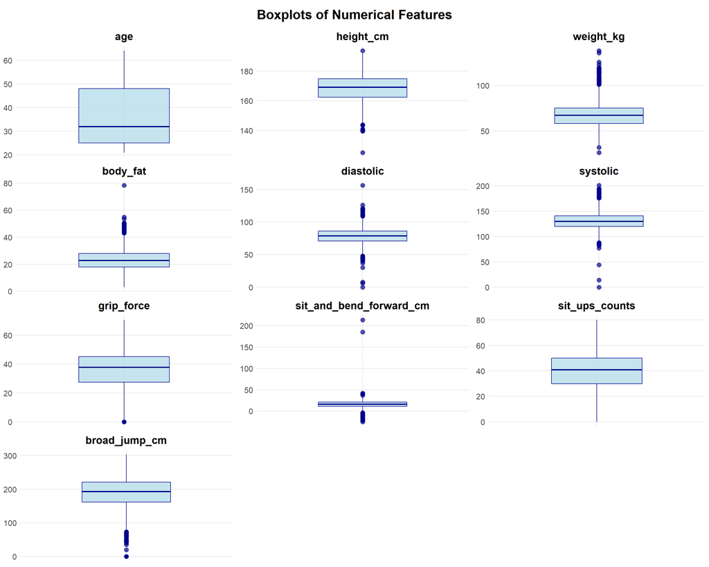

```r
boxplot_list <- list()

for (feature in numerical_features) {
  p <- ggplot(data, aes(x = "", y = .data[[feature]])) +
    geom_boxplot(fill = "lightblue", color = "darkblue", alpha = 0.7,
                 width = 0.5, outlier.size = 3) +
    labs(title = feature) +
    theme_minimal() +
    theme(
      plot.title = element_text(hjust = 0.5, size = 16, face = "bold"),
      panel.grid.major = element_line(color = "grey90"),
      panel.grid.minor = element_blank(),
      axis.title = element_blank(),
      axis.text.x = element_blank(),
      axis.text.y = element_text(size = 12)
    )
  boxplot_list[[feature]] <- p
}


grid.arrange(
  grobs = boxplot_list,
  ncol = 3,
  nrow = 4,
  top = textGrob(
    "Boxplots of Numerical Features",
    gp = gpar(fontsize = 20, fontface = "bold")
  ),
  padding = unit(2, "line")
)
```

- Nhận xét nhanh:
  - Đa số các biến đều có giá trị ngoại lai
  - Đặc biệt các biển diastolic, systolic, body_fat, sit_and_bend_forward_cm có giá trị ngoại lai không hợp lý với thực thế
  - Xem xét xóa bỏ giá trị ngoại lai hoặc thay thế

#### Xử lý dữ liệu ngoại lai

```r
# Hàm loại bỏ outliers dựa trên IQR
remove_outliers <- function(column) {
  Q1 <- quantile(column, 0.25, na.rm = TRUE)
  Q3 <- quantile(column, 0.75, na.rm = TRUE)
  IQR <- Q3 - Q1
  lower_bound <- Q1 - 1.5 * IQR
  upper_bound <- Q3 + 1.5 * IQR
  column >= lower_bound & column <= upper_bound
}

# Hàm Winsorization
winsorize <- function(column) {
  Q1 <- quantile(column, 0.25, na.rm = TRUE)
  Q3 <- quantile(column, 0.75, na.rm = TRUE)
  IQR <- Q3 - Q1
  lower_bound <- Q1 - 1.5 * IQR
  upper_bound <- Q3 + 1.5 * IQR
  column[column < lower_bound] <- lower_bound
  column[column > upper_bound] <- upper_bound
  return(column)
}

# Bắt đầu xử lý dữ liệu
data <- data %>%
  # Loại bỏ giá trị ngoại lai của diastolic và systolic
  filter(remove_outliers(diastolic), remove_outliers(systolic)) %>%
  # Loại bỏ giá trị âm và outliers quá cao của sit_and_bend_forward_cm
  filter(sit_and_bend_forward_cm >= 0) %>%
  filter(remove_outliers(sit_and_bend_forward_cm)) %>%
  # BWinsorization cho body_fat
  mutate(body_fat = winsorize(body_fat))


summary(data)
```

```
##       age           gender            height_cm       weight_kg
##  Min.   :21.00   Length:12671       Min.   :125.0   Min.   : 26.30
##  1st Qu.:25.00   Class :character   1st Qu.:162.3   1st Qu.: 57.93
##  Median :32.00   Mode  :character   Median :169.0   Median : 67.20
##  Mean   :36.76                      Mean   :168.4   Mean   : 67.14
##  3rd Qu.:48.00                      3rd Qu.:174.6   3rd Qu.: 75.00
##  Max.   :64.00                      Max.   :193.8   Max.   :138.10
##     body_fat       diastolic        systolic       grip_force
##  Min.   : 3.05   Min.   : 49.0   Min.   : 89.0   Min.   : 0.00
##  1st Qu.:17.90   1st Qu.: 71.0   1st Qu.:120.0   1st Qu.:27.50
##  Median :22.60   Median : 79.0   Median :130.0   Median :38.00
##  Mean   :23.08   Mean   : 78.8   Mean   :130.2   Mean   :37.01
##  3rd Qu.:27.80   3rd Qu.: 86.0   3rd Qu.:141.0   3rd Qu.:45.30
##  Max.   :42.65   Max.   :108.0   Max.   :171.0   Max.   :70.50
##  sit_and_bend_forward_cm sit_ups_counts  broad_jump_cm      class
##  Min.   : 0.00           Min.   : 0.00   Min.   :  0.0   Length:12671
##  1st Qu.:11.80           1st Qu.:31.00   1st Qu.:163.0   Class :character
##  Median :16.60           Median :42.00   Median :194.0   Mode  :character
##  Mean   :16.24           Mean   :40.21   Mean   :190.8
##  3rd Qu.:21.00           3rd Qu.:51.00   3rd Qu.:222.0
##  Max.   :34.80           Max.   :80.00   Max.   :303.0
```

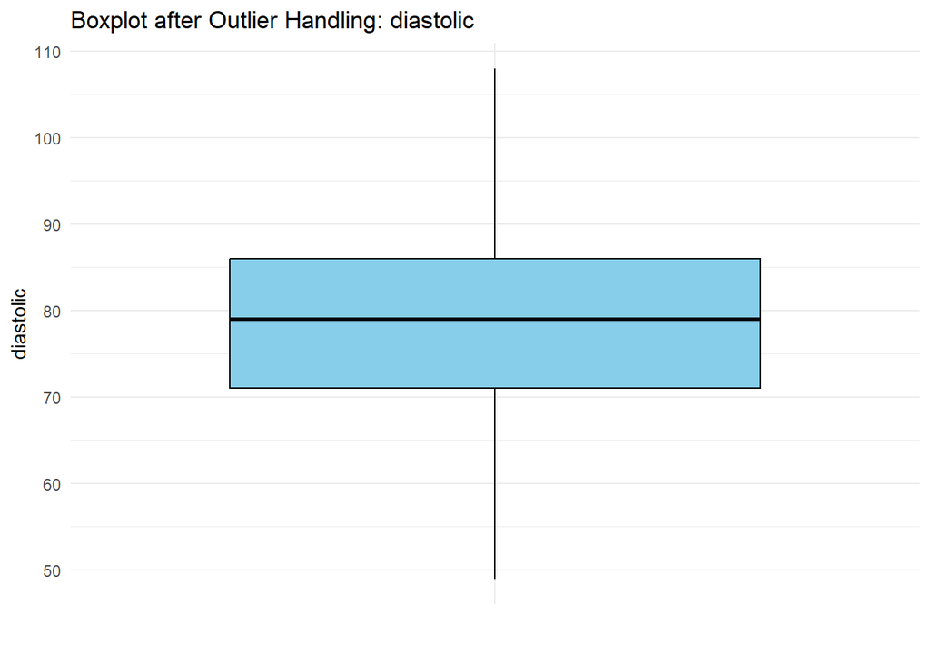

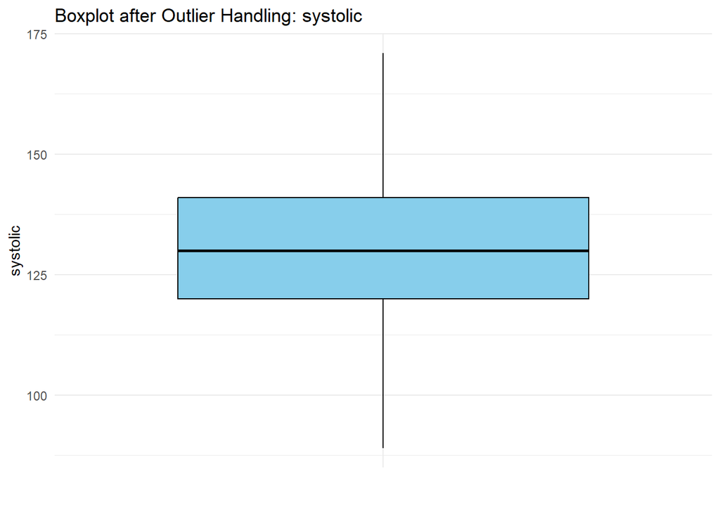

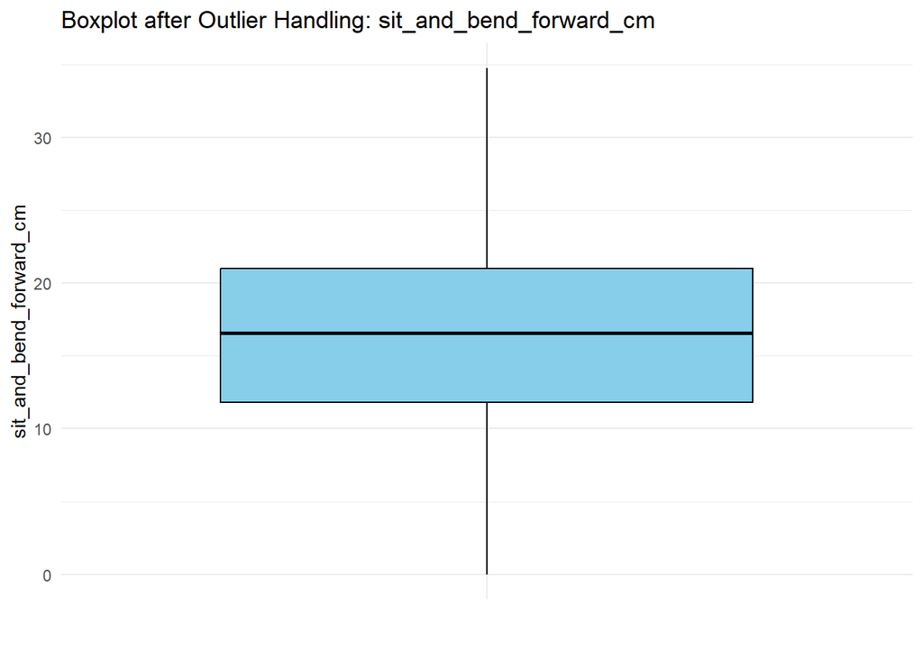

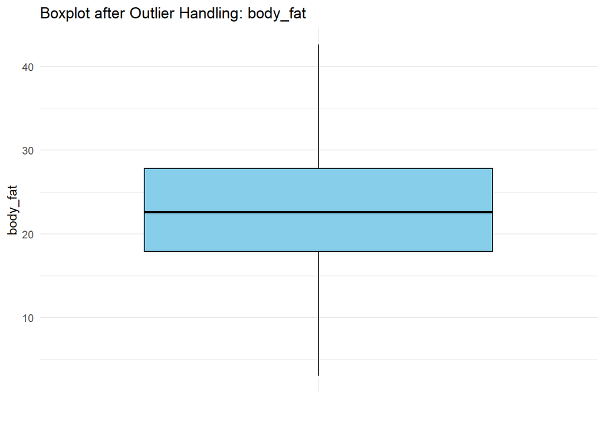

```r
for (feature in c("diastolic", "systolic", "sit_and_bend_forward_cm", "body_fat")) {
  print(
    ggplot(data, aes(x = "", y = .data[[feature]])) +
      geom_boxplot(fill = "skyblue", color = "black") +
      labs(title = paste("Boxplot after Outlier Handling:", feature), x = "", y = feature) +
      theme_minimal()
  )
}
```

## **Visualize dữ liệu đã được làm sạch**

### Biểu đồ cho “gender” và “class”

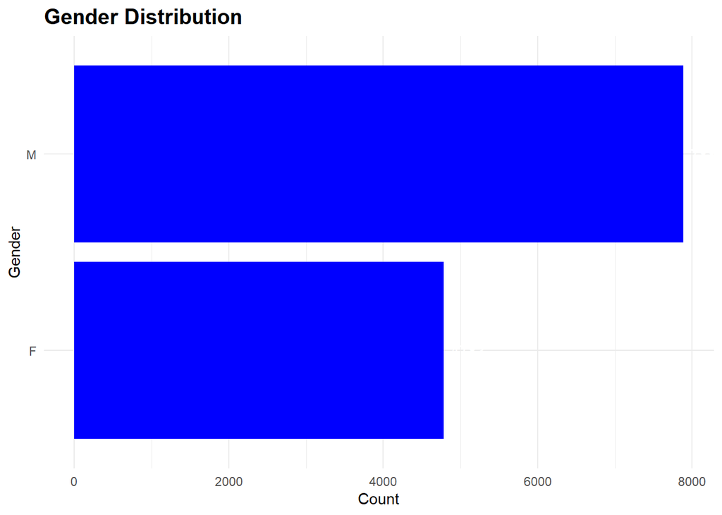

```r
ggplot(data, aes(x = gender)) +
  geom_bar(fill = "blue") +
  coord_flip() +
  geom_text(stat = "count", aes(label = after_stat(count)), hjust = -0.2, color = "white") +
  labs(title = "Gender Distribution", x = "Gender", y = "Count") +
  theme_minimal() +
  theme(plot.title = element_text(size = 15, face = "bold"))
```

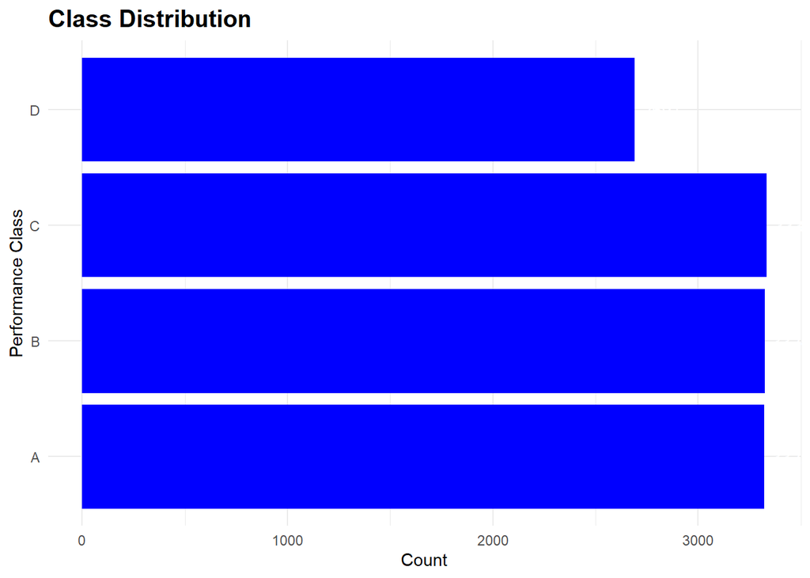

```r
ggplot(data, aes(x = class)) +
  geom_bar(fill = "blue") +
  coord_flip() +
  geom_text(stat = "count", aes(label = after_stat(count)), hjust = -0.2, color = "white") +
  labs(title = "Class Distribution", x = "Performance Class", y = "Count") +
  theme_minimal() +
  theme(plot.title = element_text(size = 15, face = "bold"))
```

```r
table( data$class)
```

```
##
##    A    B    C    D
## 3322 3324 3334 2691
```

- Thông qua biểu đồ với dữ liệu đã được xử lý, có sự mất cân bằng ở class D so với các class còn lại.

### Biểu đồ tần số và ước lượng hàm mật độ xác suất của từng biến định lượng

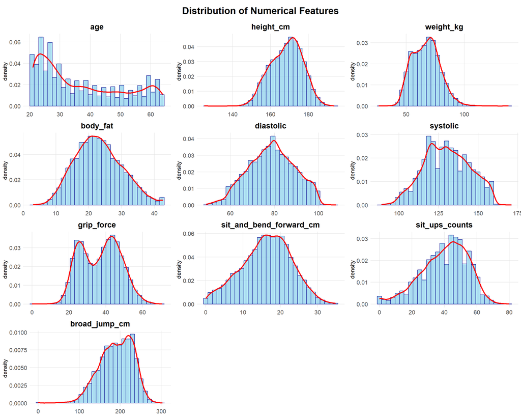

```r
hist_plots <- list()

for (var in numerical_features) {
  p <- ggplot(data, aes(x = .data[[var]])) +
    geom_histogram(aes(y = after_stat(density)),
                  fill = "skyblue",
                  color = "darkblue",
                  alpha = 0.7,
                  bins = 30) +
    geom_density(color = "red", linewidth = 1.2) +
    labs(title = var) +
    theme_minimal() +
    theme(
      plot.title = element_text(hjust = 0.5, size = 16, face = "bold"),
      panel.grid.major = element_line(color = "grey90"),
      panel.grid.minor = element_blank(),
      axis.title.x = element_blank(),
      axis.title.y = element_text(size = 12),
      axis.text = element_text(size = 12)
    )
  hist_plots[[var]] <- p
}

grid.arrange(
  grobs = hist_plots,
  ncol = 3,
  nrow = 4,
  top = textGrob(
    "Distribution of Numerical Features",
    gp = gpar(fontsize = 20, fontface = "bold")
  ),
  padding = unit(2, "line")
)
```

### Phân tích tương quan

```r
numeric_df <- data[, numerical_features]
cor_body <- cor(numeric_df, method = "pearson")
cor_body
```

```
##                                 age  height_cm  weight_kg    body_fat
## age                      1.00000000 -0.2961313 -0.1055075  0.24448506
## height_cm               -0.29613126  1.0000000  0.7387193 -0.53708051
## weight_kg               -0.10550746  0.7387193  1.0000000 -0.11930143
## body_fat                 0.24448506 -0.5370805 -0.1193014  1.00000000
## diastolic                0.15310248  0.1484005  0.2609911  0.03928072
## systolic                 0.20363707  0.2156314  0.3419174 -0.04280930
## grip_force              -0.18357680  0.7435728  0.7161117 -0.55349151
## sit_and_bend_forward_cm -0.09979886 -0.2272684 -0.3049417 -0.02801400
## sit_ups_counts          -0.55063401  0.5223872  0.3253711 -0.61027811
## broad_jump_cm           -0.43906540  0.6900669  0.5061549 -0.67736980
##                           diastolic    systolic grip_force
## age                      0.15310248  0.20363707 -0.1835768
## height_cm                0.14840053  0.21563143  0.7435728
## weight_kg                0.26099112  0.34191741  0.7161117
## body_fat                 0.03928072 -0.04280930 -0.5534915
## diastolic                1.00000000  0.67517168  0.2050871
## systolic                 0.67517168  1.00000000  0.2904953
## grip_force               0.20508709  0.29049529  1.0000000
## sit_and_bend_forward_cm -0.09073503 -0.10908142 -0.1610210
## sit_ups_counts           0.02490216  0.06560351  0.5852108
## broad_jump_cm            0.10374325  0.16189360  0.7525447
##                         sit_and_bend_forward_cm sit_ups_counts broad_jump_cm
## age                                 -0.09979886    -0.55063401   -0.43906540
## height_cm                           -0.22726842     0.52238718    0.69006691
## weight_kg                           -0.30494174     0.32537111    0.50615489
## body_fat                            -0.02801400    -0.61027811   -0.67736980
## diastolic                           -0.09073503     0.02490216    0.10374325
## systolic                            -0.10908142     0.06560351    0.16189360
## grip_force                          -0.16102102     0.58521077    0.75254470
## sit_and_bend_forward_cm              1.00000000     0.13459657   -0.02331903
## sit_ups_counts                       0.13459657     1.00000000    0.75142710
## broad_jump_cm                       -0.02331903     0.75142710    1.00000000
```

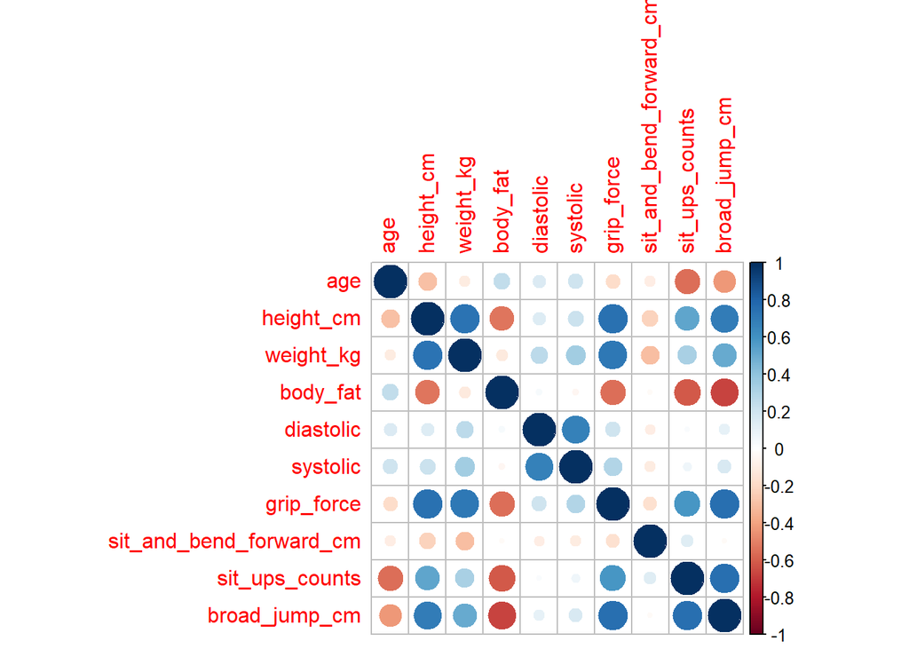

```r
corrplot(cor_body)
```

## Thực hiện một số kiểm định

### Biểu đồ kết hợp boxplot và violin plot cho các biến

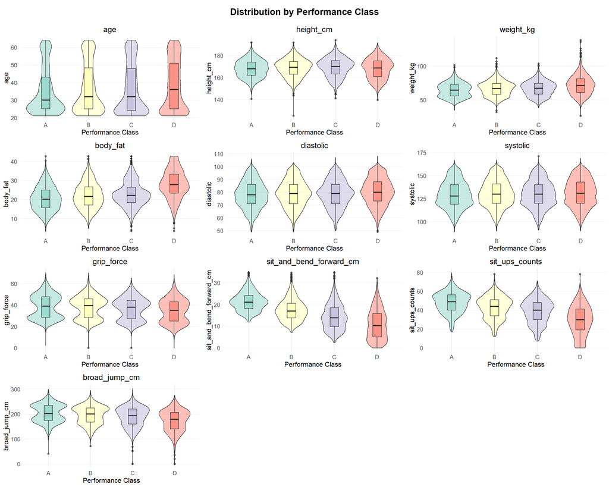

```r
violin_box_list <- list()

for(var in numerical_features) {
  violin_box_list[[var]] <- ggplot(data, aes(x = class, y = .data[[var]], fill = class)) +
    geom_violin(alpha = 0.5) +
    geom_boxplot(width = 0.2, alpha = 0.7) +
    scale_fill_brewer(palette = "Set3") +
    labs(
      title = paste(var),
      x = "Performance Class",
      y = var
    ) +
    theme_minimal() +
    theme(
      plot.title = element_text(size = 14, hjust = 0.5),
      axis.title = element_text(size = 12),
      axis.text = element_text(size = 10),
      panel.grid.major = element_line(color = "grey90"),
      panel.grid.minor = element_blank(),
      legend.position = "none",
      panel.grid.major.y = element_line(color = "grey90", size = 0.3)
    )
}
grid.arrange(
  grobs = violin_box_list,
  ncol = 3,
  nrow = 4,
  top = textGrob(
    "Distribution by Performance Class",
    gp = gpar(fontsize = 16, fontface = "bold")
  ),
  padding = unit(2, "line")
)
```

### So sánh các biến định lượng giữa các lớp hiệu suất

```r
set.seed(54)

anova_results <- list()
plot_list <- list()

for(i in numerical_features) {
    out_aov <- aovp(formula = data[[i]] ~ class, data = data, perm = "Prob")
    anova_results[[i]] <- summary(out_aov)

    p <- ggplot(data, aes(x = class, y = .data[[i]], fill = class)) +
        geom_boxplot() +
        labs(title = paste("Distribution of", i, "by Performance Class"),
             x = "Performance Class",
             y = i) +
        theme_minimal() +
        theme(legend.position = "none") +
        scale_fill_brewer(palette = "Set3")

    plot_list[[i]] <- p

    # In kết quả ANOVA
    print(paste("ANOVA Results for", i))
    print(summary(out_aov))
    cat("\n--------------------------------------------------------------\n")
}
```

```
## [1] "Settings:  unique SS "
## [1] "ANOVA Results for age"
## Component 1 :
##                Df R Sum Sq R Mean Sq Iter  Pr(Prob)
## class1          3    15250    5083.3 5000 < 2.2e-16 ***
## Residuals   12667  2337658     184.5
## ---
## Signif. codes:  0 '***' 0.001 '**' 0.01 '*' 0.05 '.' 0.1 ' ' 1
##
##
## --------------------------------------------------------------
## [1] "Settings:  unique SS "
## [1] "ANOVA Results for height_cm"
## Component 1 :
##                Df R Sum Sq R Mean Sq Iter  Pr(Prob)
## class1          3     3728   1242.55 5000 < 2.2e-16 ***
## Residuals   12667   894578     70.62
## ---
## Signif. codes:  0 '***' 0.001 '**' 0.01 '*' 0.05 '.' 0.1 ' ' 1
##
##
## --------------------------------------------------------------
## [1] "Settings:  unique SS "
## [1] "ANOVA Results for weight_kg"
## Component 1 :
##                Df R Sum Sq R Mean Sq Iter  Pr(Prob)
## class1          3    78306   26102.0 5000 < 2.2e-16 ***
## Residuals   12667  1679470     132.6
## ---
## Signif. codes:  0 '***' 0.001 '**' 0.01 '*' 0.05 '.' 0.1 ' ' 1
##
##
## --------------------------------------------------------------
## [1] "Settings:  unique SS "
## [1] "ANOVA Results for body_fat"
## Component 1 :
##                Df R Sum Sq R Mean Sq Iter  Pr(Prob)
## class1          3    92861     30954 5000 < 2.2e-16 ***
## Residuals   12667   557780        44
## ---
```

[output cut: 55 more lines]

```
## Signif. codes:  0 '***' 0.001 '**' 0.01 '*' 0.05 '.' 0.1 ' ' 1
##
##
## --------------------------------------------------------------
## [1] "Settings:  unique SS "
## [1] "ANOVA Results for broad_jump_cm"
## Component 1 :
##                Df R Sum Sq R Mean Sq Iter  Pr(Prob)
## class1          3  1414897    471632 5000 < 2.2e-16 ***
## Residuals   12667 18722617      1478
## ---
## Signif. codes:  0 '***' 0.001 '**' 0.01 '*' 0.05 '.' 0.1 ' ' 1
##
##
## --------------------------------------------------------------
```

```r
anova_summary <- data.frame(
    Variable = character(),
    F_value = numeric(),
    P_value = numeric(),
    Significant = character(),
    stringsAsFactors = FALSE
)
```

- Tất cả các biến đều có p-value rất nhỏ, cho thấy sự khác biệt có ý nghĩa thống kê.
- **Phân tích theo nhóm chỉ số**:
  - **Chỉ số sức mạnh** (grip_force, broad_jump_cm):
    - Có sự phân biệt rõ rệt giữa các class
    - Class A và B thể hiện ưu thế vượt trội
- **Chỉ số sức bền** (sit_ups_counts):
  - Sự khác biệt tăng dần theo class
  - Class A thể hiện khả năng vượt trội đáng kể
- **Chỉ số thể trạng** (body_fat, weight_kg):
  - Có xu hướng giảm dần từ class D đến A
  - Class A có tỷ lệ mỡ cơ thể thấp nhất

**Ý nghĩa**: - Các chỉ số thể chất đều có vai trò quan trọng trong việc phân loại hiệu suất - Sức mạnh và sức bền là yếu tố phân biệt rõ rệt nhất giữa các class - Thể trạng (đặc biệt là tỷ lệ mỡ cơ thể) có ảnh hưởng đáng kể đến hiệu suất - Các chỉ số sức khỏe (huyết áp) tuy ít ảnh hưởng hơn nhưng vẫn có ý nghĩa thống kê

#### Phân tích đặc điểm nhóm hiệu suất cao (Class A)

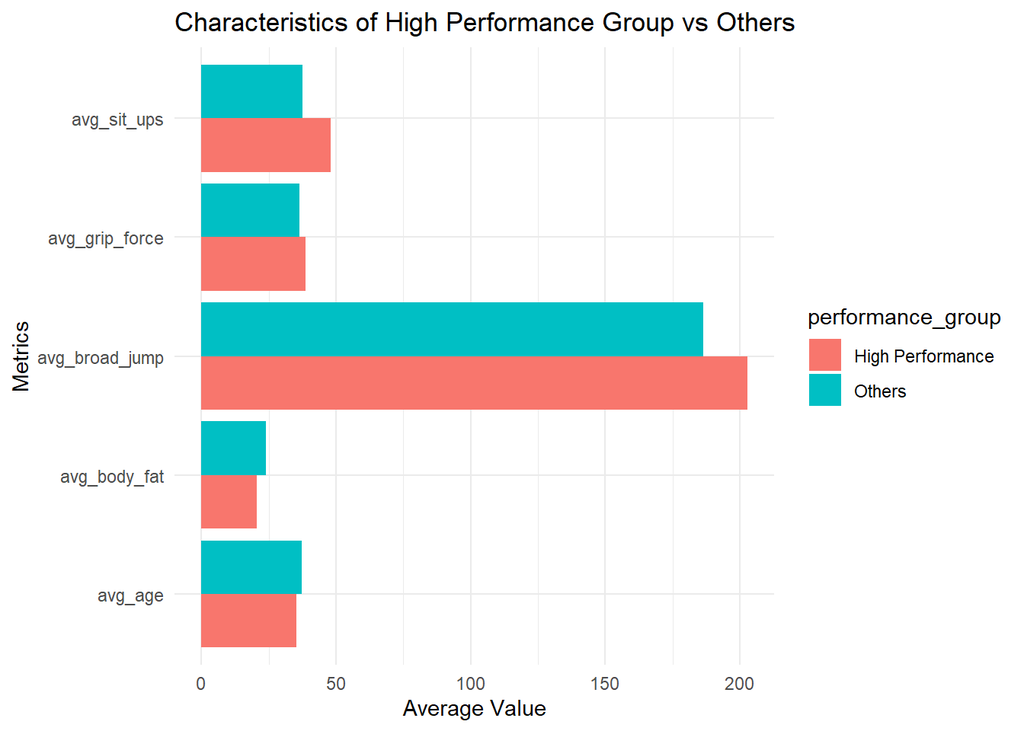

```r
# So sánh các chỉ số giữa Class A và các class khác
class_comparison <- data %>%
  mutate(performance_group = ifelse(class == "A", "High Performance", "Others")) %>%
  group_by(performance_group) %>%
  summarise(
    avg_age = mean(age),
    avg_body_fat = mean(body_fat),
    avg_grip_force = mean(grip_force),
    avg_sit_ups = mean(sit_ups_counts),
    avg_broad_jump = mean(broad_jump_cm)
  )

# Visualize sự khác biệt
class_comparison_long <- class_comparison %>%
  pivot_longer(cols = starts_with("avg_"),
               names_to = "metric",
               values_to = "value")

ggplot(class_comparison_long,
       aes(x = metric, y = value, fill = performance_group)) +
  geom_bar(stat = "identity", position = "dodge") +
  coord_flip() +
  labs(title = "Characteristics of High Performance Group vs Others",
       x = "Metrics",
       y = "Average Value") +
  theme_minimal()
```

### Phân tích ảnh hưởng của giới tính đến hiệu suất

```r
important_vars <- c("age", "body_fat", "grip_force", "sit_ups_counts", "broad_jump_cm")

# Kiểm định Permutation ANOVA hai chiều cho tương tác giữa giới tính và hiệu suất
cat("\nKết quả Permutation ANOVA hai chiều (Gender x Class):\n")
```

```
##
## Kết quả Permutation ANOVA hai chiều (Gender x Class):
```

```r
for(var in important_vars) {
    formula <- as.formula(paste(var, "~ gender * class"))
    out_aov <- aovp(formula, data = data, perm = "Prob")
    cat(sprintf("\nPermutation ANOVA hai chiều cho %s:\n", var))
    print(summary(out_aov))
}
```

```
## [1] "Settings:  unique SS "
##
## Permutation ANOVA hai chiều cho age:
## Component 1 :
##                   Df R Sum Sq R Mean Sq Iter  Pr(Prob)
## gender1            1    13822   13822.4 5000 < 2.2e-16 ***
## class1             3    25025    8341.6 5000 < 2.2e-16 ***
## gender1:class1     3    36706   12235.4 5000 < 2.2e-16 ***
## Residuals      12663  2290791     180.9
## ---
## Signif. codes:  0 '***' 0.001 '**' 0.01 '*' 0.05 '.' 0.1 ' ' 1
##
## [1] "Settings:  unique SS "
##
## Permutation ANOVA hai chiều cho body_fat:
## Component 1 :
##                   Df R Sum Sq R Mean Sq Iter  Pr(Prob)
## gender1            1   220348    220348 5000 < 2.2e-16 ***
## class1             3    96500     32167 5000 < 2.2e-16 ***
## gender1:class1     3      384       128 5000 < 2.2e-16 ***
## Residuals      12663   335356        26
## ---
## Signif. codes:  0 '***' 0.001 '**' 0.01 '*' 0.05 '.' 0.1 ' ' 1
##
## [1] "Settings:  unique SS "
##
## Permutation ANOVA hai chiều cho grip_force:
## Component 1 :
##                   Df R Sum Sq R Mean Sq Iter  Pr(Prob)
## gender1            1   953074    953074 5000 < 2.2e-16 ***
## class1             3    45969     15323 5000 < 2.2e-16 ***
## gender1:class1     3      607       202 5000 < 2.2e-16 ***
## Residuals      12663   451887        36
## ---
## Signif. codes:  0 '***' 0.001 '**' 0.01 '*' 0.05 '.' 0.1 ' ' 1
##
## [1] "Settings:  unique SS "
##
## Permutation ANOVA hai chiều cho sit_ups_counts:
## Component 1 :
##                   Df R Sum Sq R Mean Sq Iter  Pr(Prob)
## gender1            1   699735    699735 5000 < 2.2e-16 ***
## class1             3   608187    202729 5000 < 2.2e-16 ***
## gender1:class1     3    26115      8705 5000 < 2.2e-16 ***
## Residuals      12663  1312700       104
## ---
## Signif. codes:  0 '***' 0.001 '**' 0.01 '*' 0.05 '.' 0.1 ' ' 1
##
## [1] "Settings:  unique SS "
##
## Permutation ANOVA hai chiều cho broad_jump_cm:
## Component 1 :
##                   Df R Sum Sq R Mean Sq Iter  Pr(Prob)
## gender1            1 10838491  10838491 5000 < 2.2e-16 ***
## class1             3  1833902    611301 5000 < 2.2e-16 ***
## gender1:class1     3    46437     15479 5000 < 2.2e-16 ***
## Residuals      12663  7869750       621
## ---
## Signif. codes:  0 '***' 0.001 '**' 0.01 '*' 0.05 '.' 0.1 ' ' 1
```

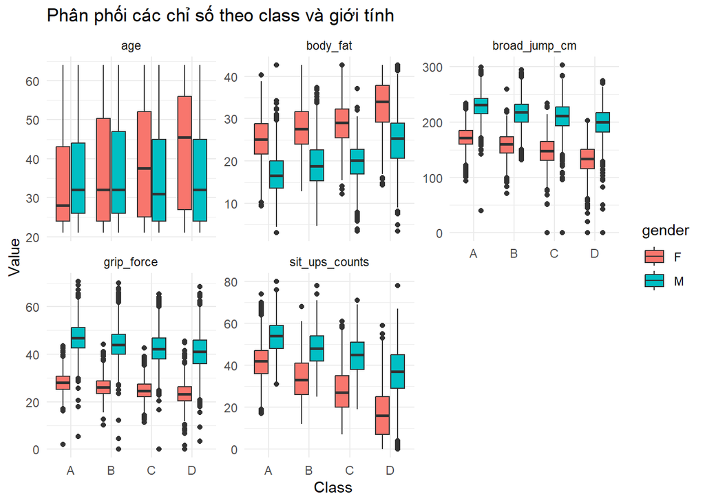

```r
data_long <- data %>%
  pivot_longer(cols = all_of(important_vars),
               names_to = "variable",
               values_to = "value")

ggplot(data_long, aes(x = class, y = value, fill = gender)) +
  geom_boxplot() +
  facet_wrap(~variable, scales = "free_y") +
  labs(title = "Phân phối các chỉ số theo class và giới tính",
       x = "Class",
       y = "Value") +
  theme_minimal()
```

```r
performance_stats <- data %>%
  group_by(gender, class) %>%
  summarise(
    count = n(),
    avg_age = mean(age),
    avg_body_fat = mean(body_fat),
    avg_grip_force = mean(grip_force),
    avg_sit_ups = mean(sit_ups_counts),
    avg_broad_jump = mean(broad_jump_cm)
  ) %>%
  group_by(gender) %>%
  mutate(percentage = count/sum(count) * 100)
print("\nThống kê theo giới tính và class:")
```

```
## [1] "\nThống kê theo giới tính và class:"
```

```r
print(performance_stats)
```

```
## # A tibble: 8 × 9
## # Groups:   gender [2]
##   gender class count avg_age avg_body_fat avg_grip_force avg_sit_ups
##   <chr>  <chr> <int>   <dbl>        <dbl>          <dbl>       <dbl>
## 1 F      A      1475    34.0         25.1           28.2        41.3
## 2 F      B      1176    37.2         27.6           26.3        33.7
## 3 F      C      1106    38.9         28.8           24.8        27.9
## 4 F      D      1026    42.9         33.3           23.4        17.2
## 5 M      A      1847    36.2         16.9           47.0        53.1
## 6 M      B      2148    37.0         19.0           44.3        47.6
## 7 M      C      2228    35.6         19.6           42.5        44.1
## 8 M      D      1665    35.6         24.8           41.1        37.2
## # ℹ 2 more variables: avg_broad_jump <dbl>, percentage <dbl>
```

## **Model**

Hàm đánh giá mô hình

```r
eval_multi_class <- function(x) {
  cc <- sum(diag(x))
  sc <- sum(x)
  pp <- colSums(x)
  tt <- rowSums(x)

  # Precision và Recall cho từng lớp
  prec <- diag(x) / pp
  recall <- diag(x) / tt

  # Macro Precision, Recall và F1
  macro_prec <- mean(prec, na.rm = TRUE)
  macro_recall <- mean(recall, na.rm = TRUE)
  macro_f1 <- 2 * macro_prec * macro_recall / (macro_prec + macro_recall)

  # Accuracy
  acc <- cc / sc

  # Kappa
  kap <- (cc * sc - sum(pp * tt)) / (sc^2 - sum(pp * tt))

  return(list(
    Precision = prec,
    Recall = recall,
    Accuracy = acc,
    Kappa = kap,
    Macro_F1 = macro_f1
  ))
}
```

### Chia bộ dữ liệu

```r
set.seed(123)
split <- initial_split(data, prop = 0.8, strata = class)
train <- training(split)
test <- testing(split)

# Kiểm tra kích thước các tập
cat("Train size: ", dim(train), "\n")
```

```
## Train size:  10135 12
```

```r
cat("Test size: ", dim(test), "\n")
```

```
## Test size:  2536 12
```

```r
# Kiểm tra kiểu dữ liệu ban đầu
str(train$class)
```

```
##  chr [1:10135] "A" "A" "A" "A" "A" "A" "A" "A" "A" "A" "A" "A" "A" "A" "A" ...
```

```r
str(test$class)
```

```
##  chr [1:2536] "C" "B" "C" "A" "B" "C" "B" "B" "C" "C" "A" "B" "D" "B" "C" ...
```

```r
# Chuyển đổi các biến phân loại thành factor
train <- train %>%
  mutate(
    class = as.factor(class),
    gender = as.factor(gender)
  )

test <- test %>%
  mutate(
    class = as.factor(class),
    gender = as.factor(gender)
  )
str(train$class)
```

```
##  Factor w/ 4 levels "A","B","C","D": 1 1 1 1 1 1 1 1 1 1 ...
```

```r
str(test$class)
```

```
##  Factor w/ 4 levels "A","B","C","D": 3 2 3 1 2 3 2 2 3 3 ...
```

### Thực hiện cân bằng dữ liệu với SMOTE

```r
library(themis)
library(recipes)
library(tidymodels)

original_distribution <- table(train$class)

recipe_obj <- recipe(class ~ ., data = train) %>%
  step_smotenc(class)

data_balanced <- prep(recipe_obj) %>%
  bake(new_data = NULL)

cat("Phân phối class trước khi cân bằng:\n")
```

```
## Phân phối class trước khi cân bằng:
```

```r
print(original_distribution)
```

```
##
##    A    B    C    D
## 2657 2659 2667 2152
```

```r
cat("\nPhân phối class sau khi cân bằng:\n")
```

```
##
## Phân phối class sau khi cân bằng:
```

```r
print(table(data_balanced$class))
```

```
##
##    A    B    C    D
## 2667 2667 2667 2667
```

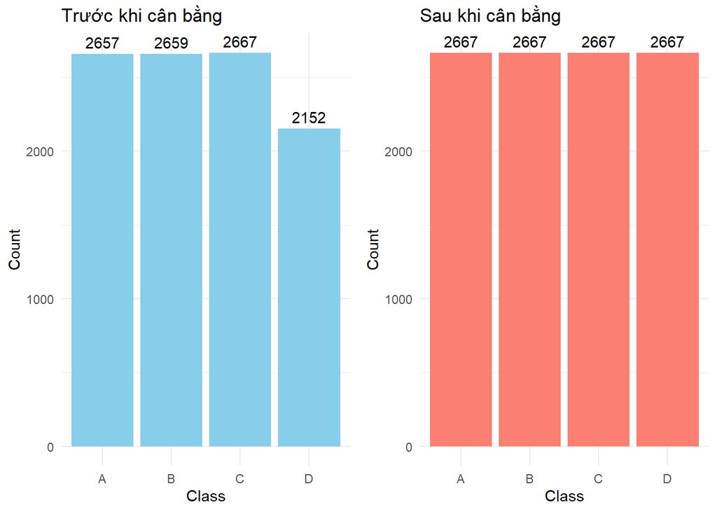

```r
# Trực quan hóa kết quả
p1 <- ggplot(train, aes(x = class)) +
  geom_bar(fill = "skyblue") +
  geom_text(stat = "count", aes(label = after_stat(count)), vjust = -0.5) +
  labs(title = "Trước khi cân bằng",
       x = "Class",
       y = "Count") +
  theme_minimal()

p2 <- ggplot(data_balanced, aes(x = class)) +
  geom_bar(fill = "salmon") +
  geom_text(stat = "count", aes(label = after_stat(count)), vjust = -0.5) +
  labs(title = "Sau khi cân bằng",
       x = "Class",
       y = "Count") +
  theme_minimal()

# Hiển thị cả hai biểu đồ
library(gridExtra)
grid.arrange(p1, p2, ncol = 2)
```

```r
summary(data_balanced)
```

```
##       age        gender     height_cm       weight_kg         body_fat
##  Min.   :21.00   F:4019   Min.   :125.0   Min.   : 33.70   Min.   : 3.05
##  1st Qu.:25.00   M:6649   1st Qu.:162.3   1st Qu.: 58.10   1st Qu.:18.00
##  Median :32.00            Median :169.0   Median : 67.50   Median :22.90
##  Mean   :36.93            Mean   :168.4   Mean   : 67.36   Mean   :23.31
##  3rd Qu.:48.00            3rd Qu.:174.7   3rd Qu.: 75.20   3rd Qu.:28.20
##  Max.   :64.00            Max.   :193.8   Max.   :138.10   Max.   :42.65
##    diastolic         systolic       grip_force    sit_and_bend_forward_cm
##  Min.   : 49.00   Min.   : 89.0   Min.   : 0.00   Min.   : 0.00
##  1st Qu.: 72.00   1st Qu.:120.0   1st Qu.:27.30   1st Qu.:11.40
##  Median : 79.00   Median :130.0   Median :37.92   Median :16.30
##  Mean   : 78.94   Mean   :130.4   Mean   :36.95   Mean   :15.96
##  3rd Qu.: 86.17   3rd Qu.:141.0   3rd Qu.:45.30   3rd Qu.:20.80
##  Max.   :107.00   Max.   :171.0   Max.   :70.50   Max.   :34.80
##  sit_ups_counts  broad_jump_cm class
##  Min.   : 0.00   Min.   :  0   A:2667
##  1st Qu.:30.00   1st Qu.:162   B:2667
##  Median :41.00   Median :193   C:2667
##  Mean   :39.77   Mean   :190   D:2667
##  3rd Qu.:51.00   3rd Qu.:222
##  Max.   :80.00   Max.   :303
```

```r
data <- data_balanced
```

### Multinomial Logistic Regression

#### Huấn luyện mô hình Multinomial Logistic Regression cơ bản

```r
multinom_model <- multinom(class ~ ., data = train, maxit = 100)
pred <-  predict(multinom_model, newdata = test, type = "class")
head(pred)
```

```
## [1] A D C B C C
## Levels: A B C D
```

```r
# Tạo confusion matrix từ dự đoán
multinom_conf_mat <- tibble(
  truth = test$class,
  prediction = pred
) %>%
  conf_mat(truth = truth, estimate = prediction)

# Đánh giá mô hình
metrics_multinom <- eval_multi_class(multinom_conf_mat$table)
print(metrics_multinom)
```

```
## $Precision
##         A         B         C         D
## 0.7398496 0.4285714 0.5337331 0.7142857
##
## $Recall
##         A         B         C         D
## 0.6929577 0.4649266 0.5258493 0.7182836
##
## $Accuracy
## [1] 0.5985804
##
## $Kappa
## [1] 0.4633906
##
## $Macro_F1
## [1] 0.6023017
```

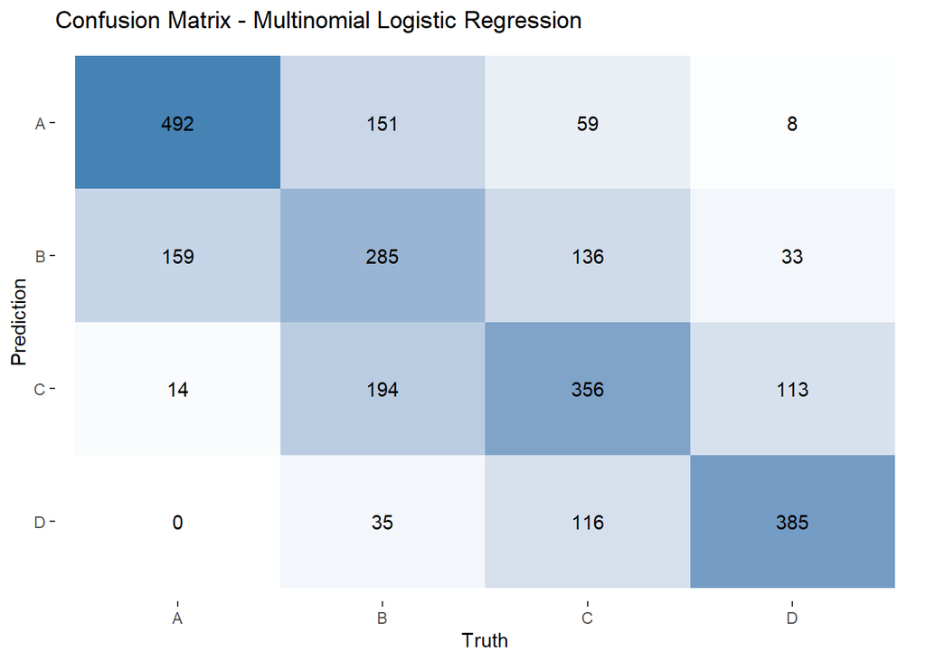

```r
# Trực quan hóa Confusion Matrix
autoplot(multinom_conf_mat, type = "heatmap") +
  scale_fill_gradient(low = "white", high = "steelblue") +
  labs(title = "Confusion Matrix - Multinomial Logistic Regression")
```

```r
multinom_model_simplified <- multinom(
  class ~ gender + age + diastolic + systolic + height_cm +
    I(log(grip_force + 1)) +
    I(log(sit_ups_counts + 1)) +
    I(log(broad_jump_cm + 1)) +
    I(weight_kg * (body_fat/100)) +
    sit_and_bend_forward_cm,
  data = train,
  maxit = 1000
)
pred_simplified <- predict(multinom_model_simplified, newdata = test, type = "class")
head(pred_simplified)
```

```
## [1] A D D B C B
## Levels: A B C D
```

```r
# Confusion Matrix
multinom_conf_mat_simplified <- tibble(
  truth = test$class,
  prediction = pred_simplified
) %>%
  conf_mat(truth = truth, estimate = prediction)

print(multinom_conf_mat_simplified)
```

```
##           Truth
## Prediction   A   B   C   D
##          A 494 154  62  11
##          B 159 297 135  33
##          C  11 187 373 105
##          D   1  27  97 390
```

```r
# Đánh giá mô hình
metrics_simplified <-eval_multi_class(multinom_conf_mat_simplified$table)
print(metrics_simplified)
```

```
## $Precision
##         A         B         C         D
## 0.7428571 0.4466165 0.5592204 0.7235622
##
## $Recall
##         A         B         C         D
## 0.6851595 0.4759615 0.5517751 0.7572816
##
## $Accuracy
## [1] 0.612776
##
## $Kappa
## [1] 0.4820824
##
## $Macro_F1
## [1] 0.6178041
```

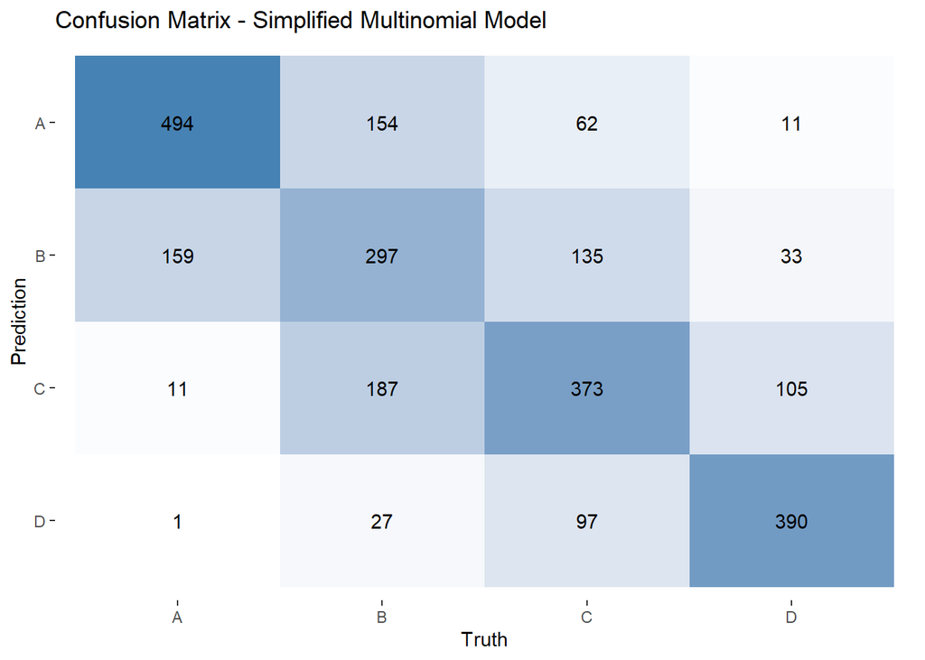

```r
# Trực quan hóa Confusion Matrix
autoplot(multinom_conf_mat_simplified, type = "heatmap") +
  scale_fill_gradient(low = "white", high = "steelblue") +
  labs(title = "Confusion Matrix - Simplified Multinomial Model")
```

### Huấn luyện mô hình Random Forest

```r
library(randomForest)
rf_model <- randomForest(class ~ ., data = train)
pred_rf <- predict(rf_model, newdata = test, type = "class")
head(pred_rf)
```

```
## 1 2 3 4 5 6
## A D C B A B
## Levels: A B C D
```

```r
# Confusion Matrix
rf_conf_mat <- tibble(
  truth = test$class,
  prediction = pred_rf
) %>%
  conf_mat(truth = truth, estimate = prediction)

print(rf_conf_mat)
```

```
##           Truth
## Prediction   A   B   C   D
##          A 571 149  62   9
##          B  83 399 129  28
##          C   8  85 441  90
##          D   3  32  35 412
```

```r
# Đánh giá mô hình
metrics_rf <- eval_multi_class(rf_conf_mat$table)
print(metrics_rf)
```

```
## $Precision
##         A         B         C         D
## 0.8586466 0.6000000 0.6611694 0.7643785
##
## $Recall
##         A         B         C         D
## 0.7218710 0.6244131 0.7067308 0.8547718
##
## $Accuracy
## [1] 0.7188486
##
## $Kappa
## [1] 0.6236386
##
## $Macro_F1
## [1] 0.7239856
```

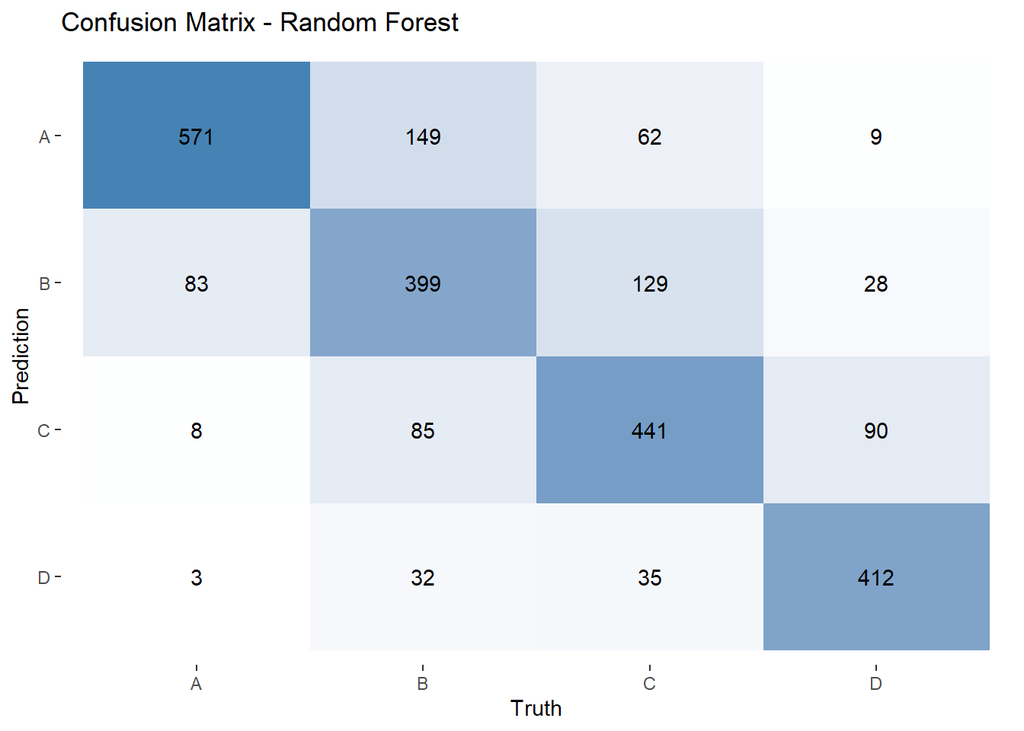

```r
# Trực quan hóa Confusion Matrix
autoplot(rf_conf_mat, type = "heatmap") +
  scale_fill_gradient(low = "white", high = "steelblue") +
  labs(title = "Confusion Matrix - Random Forest")
```

### Huấn luyện mô hình XGBoost

```r
library(xgboost)

# Chuẩn bị dữ liệu
# Encoding cho class (A=0, B=1, C=2, D=3)
train$class_num <- as.numeric(factor(train$class, levels = c("A", "B", "C", "D"))) - 1
test$class_num <- as.numeric(factor(test$class, levels = c("A", "B", "C", "D"))) - 1

# Encoding cho gender (Female=0, Male=1)
train$gender_num <- ifelse(train$gender == "M", 1, 0)
test$gender_num <- ifelse(test$gender == "M", 1, 0)

# Chọn các cột numeric để đưa vào model
feature_cols <- c("age", "height_cm", "weight_kg", "body_fat", "diastolic",
                 "systolic", "grip_force", "sit_and_bend_forward_cm",
                 "sit_ups_counts", "broad_jump_cm", "gender_num")

# Chuyển đổi dữ liệu thành matrix
train_matrix <- as.matrix(train[, feature_cols])
test_matrix <- as.matrix(test[, feature_cols])

# Huấn luyện mô hình
xgb_model <- xgboost(data = train_matrix,
                     label = train$class_num,
                     nrounds = 100,
                     objective = "multi:softmax",
                     num_class = 4,
                     eta = 0.3,
                     max_depth = 6)
# Dự đoán
pred_xgb_num <- predict(xgb_model, test_matrix)
# Chuyển đổi dự đoán về dạng factor với thứ tự đúng
pred_xgb <- factor(pred_xgb_num, levels = 0:3, labels = c("A", "B", "C", "D"))
```

```r
# Confusion Matrix
xgb_conf_mat <- tibble(
  truth = test$class,
  prediction = factor(pred_xgb, levels = levels(test$class))
) %>%
  conf_mat(truth = truth, estimate = prediction)

print(xgb_conf_mat)
```

```
##           Truth
## Prediction   A   B   C   D
##          A 589 130  57   8
##          B  68 408 133  40
##          C   8 100 450  77
##          D   0  27  27 414
```

```r
# Đánh giá mô hình
metrics_xgb <- eval_multi_class(xgb_conf_mat$table)
print(metrics_xgb)
```

```
## $Precision
##         A         B         C         D
## 0.8857143 0.6135338 0.6746627 0.7680891
##
## $Recall
##         A         B         C         D
## 0.7512755 0.6286595 0.7086614 0.8846154
##
## $Accuracy
## [1] 0.7338328
##
## $Kappa
## [1] 0.6435647
##
## $Macro_F1
## [1] 0.7393809
```

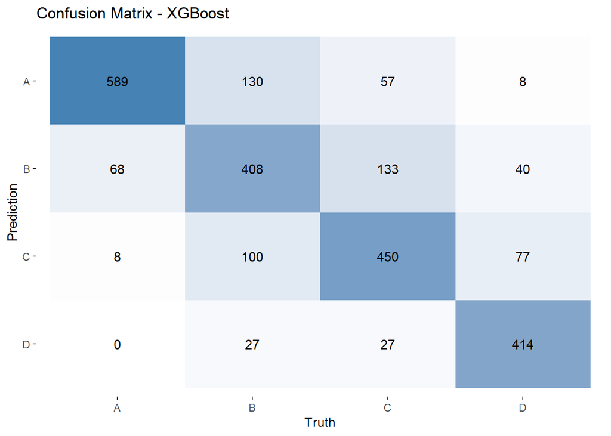

```r
# Trực quan hóa Confusion Matrix
autoplot(xgb_conf_mat, type = "heatmap") +
  scale_fill_gradient(low = "white", high = "steelblue") +
  labs(title = "Confusion Matrix - XGBoost")
```

### So sánh hiệu quả các mô hình

```r
comparison <- data.frame(
  Model = c("Basic Multinomial", "Simplified Multinomial", "Random Forest", "XGBoost"),
  Accuracy = c(metrics_multinom$Accuracy, metrics_simplified$Accuracy,
               metrics_rf$Accuracy, metrics_xgb$Accuracy),
  Kappa = c(metrics_multinom$Kappa, metrics_simplified$Kappa,
            metrics_rf$Kappa, metrics_xgb$Kappa),
  Macro_F1 = c(metrics_multinom$Macro_F1, metrics_simplified$Macro_F1,
               metrics_rf$Macro_F1, metrics_xgb$Macro_F1)
)
print(comparison)
```

```
##                    Model  Accuracy     Kappa  Macro_F1
## 1      Basic Multinomial 0.5985804 0.4633906 0.6023017
## 2 Simplified Multinomial 0.6127760 0.4820824 0.6178041
## 3          Random Forest 0.7188486 0.6236386 0.7239856
## 4                XGBoost 0.7338328 0.6435647 0.7393809
```

### Những đặc trưng quan trọng trong mô hình

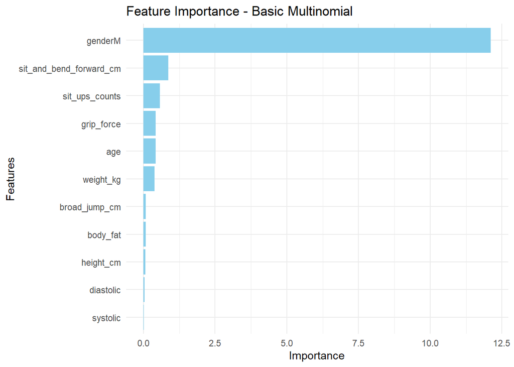

```r
# 1.Multinomial
basic_importance <- varImp(multinom_model)
ggplot(data = data.frame(
  Feature = rownames(basic_importance),
  Importance = basic_importance[,1]
)) +
  geom_bar(aes(x = reorder(Feature, Importance), y = Importance), stat = "identity", fill = "skyblue") +
  coord_flip() +
  labs(title = "Feature Importance - Basic Multinomial",
       x = "Features", y = "Importance") +
  theme_minimal()
```

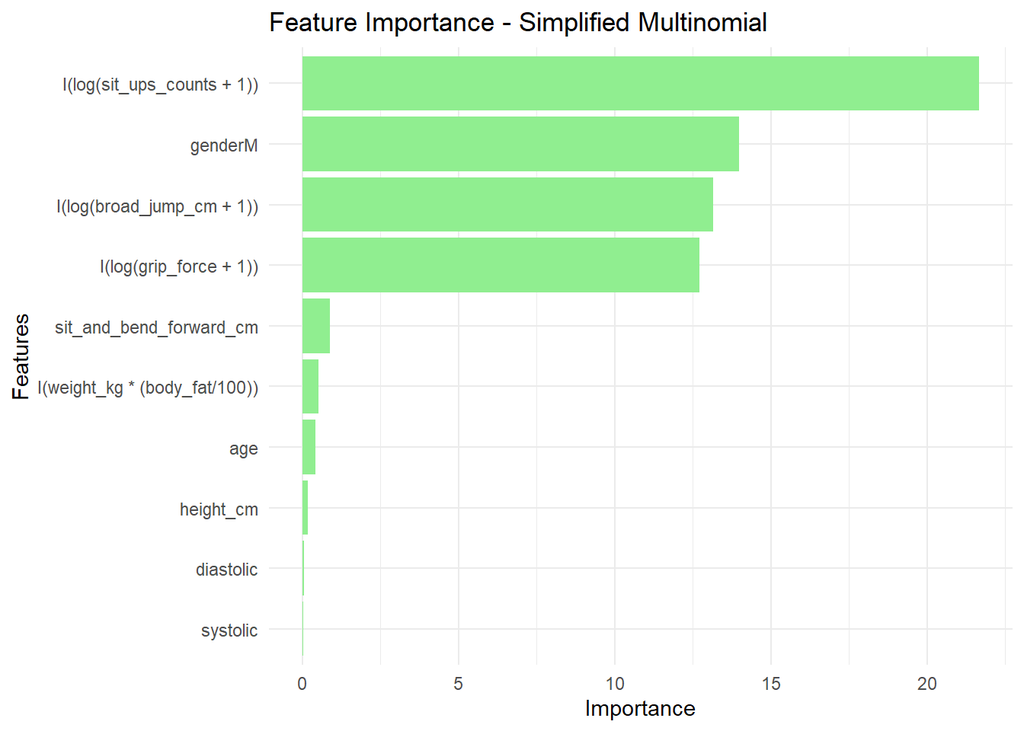

```r
# 2. Simplified Multinomial
simplified_importance <- varImp(multinom_model_simplified)
ggplot(data = data.frame(
  Feature = rownames(simplified_importance),
  Importance = simplified_importance[,1]
)) +
  geom_bar(aes(x = reorder(Feature, Importance), y = Importance), stat = "identity", fill = "lightgreen") +
  coord_flip() +
  labs(title = "Feature Importance - Simplified Multinomial",
       x = "Features", y = "Importance") +
  theme_minimal()
```

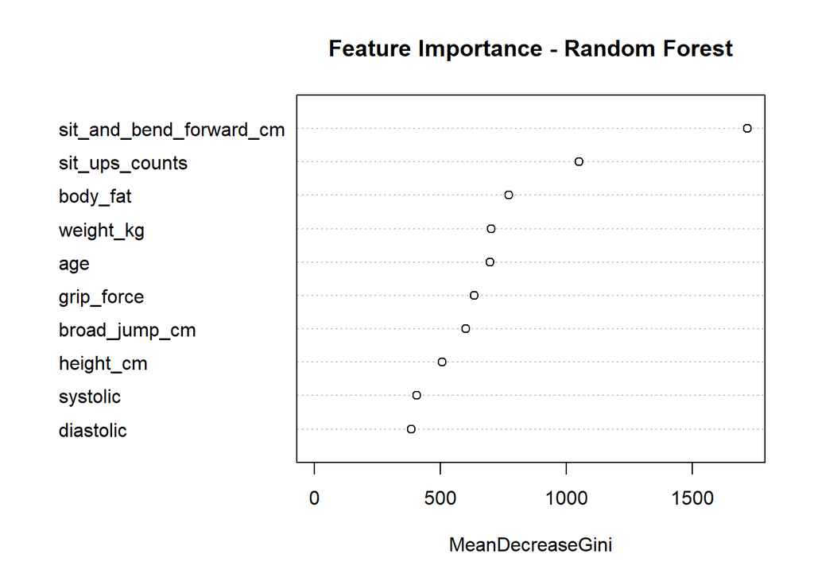

```r
# 3. Random Forest
varImpPlot(rf_model,
           sort = TRUE,
           main = "Feature Importance - Random Forest",
           n.var = min(10, ncol(train)))
```

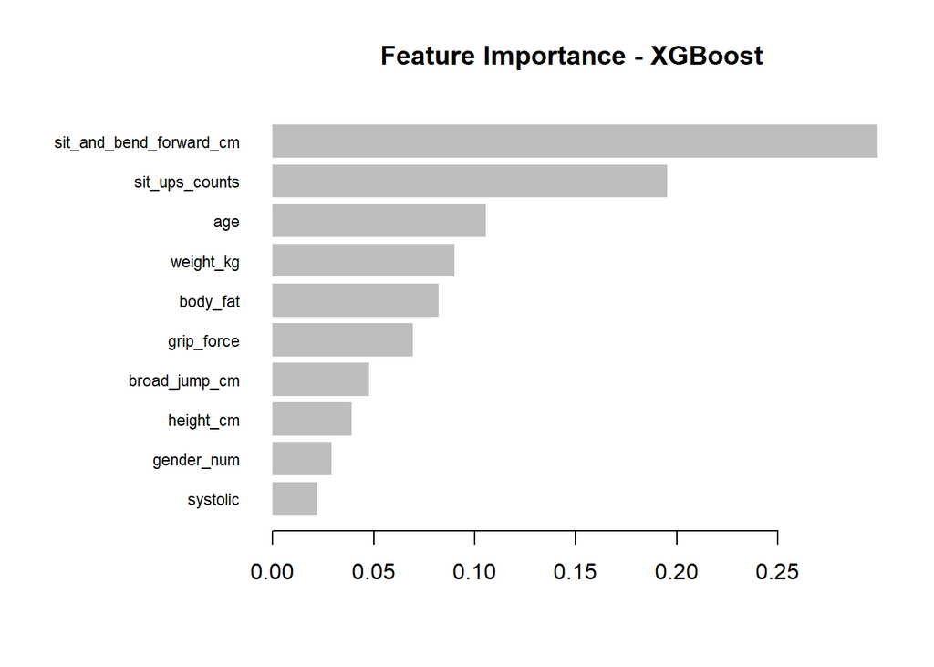

```r
# 4. XGBoost
importance_matrix <- xgb.importance(
  feature_names = feature_cols,
  model = xgb_model
)
xgb.plot.importance(importance_matrix, top_n = 10,
                   main = "Feature Importance - XGBoost")
```